# **Malaria Detection**

## **Data Description**

**Parasitized:** The parasitized cells contain the Plasmodium parasite which causes malaria  
**Uninfected:** The uninfected cells are free of the Plasmodium parasites

### **Mount the Drive**

```python
from google.colab import drive
drive.mount('/content/drive')
```

### **Loading libraries**

```python
import os

import numpy as np

import pandas as pd

import matplotlib.pyplot as plt

import seaborn as sns

from PIL import Image

import keras

import cv2

from sklearn.model_selection import train_test_split

from sklearn.preprocessing import MinMaxScaler

import tensorflow as tf

from tensorflow.keras import backend

from tensorflow.keras.models import Sequential

from tensorflow.keras.preprocessing.image import ImageDataGenerator, load_img, img_to_array

# importing optimizers
from tensorflow.keras.layers import Dense, Dropout, LeakyReLU, Flatten,MaxPooling2D, Conv2D, Activation, BatchNormalization

from tensorflow.keras.losses import categorical_crossentropy

from tensorflow.keras.optimizers import Adam, SGD

from tensorflow.keras.utils import to_categorical

from tensorflow.keras.callbacks import EarlyStopping, ModelCheckpoint

import warnings
warnings.filterwarnings("ignore")
```

### **Let us load the data**

**Note:**

- You must download the dataset from the link provided on Olympus and upload the same to your Google Drive. Then unzip the folder.

The extracted folder has different folders for train and test data will contain the different sizes of images for parasitized and uninfected cells within the respective folder name.

The size of all images must be the same and should be converted to 4D arrays so that they can be used as an input for the convolutional neural network. Also, we need to create the labels for both types of images to be able to train and test the model.

Let's do the same for the training data first and then we will use the same code for the test data as well.

```python
# Set the paths for the training data
train_path = '/content/drive/MyDrive/MITdataScienceCourse/scripts/Capstone_project/cell_images/train'
parasitized_path = os.path.join(train_path, 'parasitized')
uninfected_path = os.path.join(train_path, 'uninfected')

# Define the image size and initialize lists
image_size = (32, 32)
train_images = []
train_labels = []

# Function to load and preprocess images
def load_images_from_folder(folder, label):
    images = []
    for filename in os.listdir(folder):
        img_path = os.path.join(folder, filename)
        img = cv2.imread(img_path, cv2.IMREAD_GRAYSCALE)
        if img is not None:
            img = cv2.resize(img, image_size)
            images.append(img)
    labels = [label] * len(images)
    return images, labels

# Load and preprocess parasitized images
parasitized_images, parasitized_labels = load_images_from_folder(parasitized_path, 1)
train_images.extend(parasitized_images)
train_labels.extend(parasitized_labels)

# Load and preprocess uninfected images
uninfected_images, uninfected_labels = load_images_from_folder(uninfected_path, 0)
train_images.extend(uninfected_images)
train_labels.extend(uninfected_labels)

# Convert lists to numpy arrays
train_images = np.array(train_images)
train_labels = np.array(train_labels)

# Reshape the images to 4D arrays (samples, height, width, channels)
train_images = train_images.reshape(train_images.shape[0], image_size[0], image_size[1], 1)
```

```python
# Set the paths for the test data
test_path = '/content/drive/MyDrive/MITdataScienceCourse/scripts/Capstone_project/cell_images/test'  # Update with your actual path
parasitized_test_path = os.path.join(test_path, 'parasitized')
uninfected_test_path = os.path.join(test_path, 'uninfected')

# Initialize lists for test data
test_images = []
test_labels = []

# Load and preprocess parasitized test images
parasitized_test_images, parasitized_test_labels = load_images_from_folder(parasitized_test_path, 1)
test_images.extend(parasitized_test_images)
test_labels.extend(parasitized_test_labels)

# Load and preprocess uninfected test images
uninfected_test_images, uninfected_test_labels = load_images_from_folder(uninfected_test_path, 0)
test_images.extend(uninfected_test_images)
test_labels.extend(uninfected_test_labels)

# Convert lists to numpy arrays
test_images = np.array(test_images)
test_labels = np.array(test_labels)

# Reshape the images to 4D arrays (samples, height, width, channels)
test_images = test_images.reshape(test_images.shape[0], image_size[0], image_size[1], 1)
```

### **Check the shape of train and test images**

```python
# Print shapes for verification
print(f'Train images shape: {train_images.shape}')

# Print shapes for verification
print(f'Test images shape: {test_images.shape}')
```

```
Train images shape: (24957, 32, 32, 1)
Test images shape: (2600, 32, 32, 1)
```

### **Check the shape of train and test labels**

```python
print(f'Train labels shape: {train_labels.shape}')
print(f'Test labels shape: {test_labels.shape}')
```

```
Train labels shape: (24957,)
Test labels shape: (2600,)
```

#### **Observations and insights:**

- There are 24,957 images in the training dataset while the test data contain 2,600.
- In both datasets the images dimentions are 32x32.

### **Check the minimum and maximum range of pixel values for train and test images**

```python
# Check the minimum and maximum pixel values for train images
train_min = np.min(train_images)
train_max = np.max(train_images)

print(f'Train images pixel value range: Min = {train_min}, Max = {train_max}')

# Check the minimum and maximum pixel values for test images
test_min = np.min(test_images)
test_max = np.max(test_images)

print(f'Test images pixel value range: Min = {test_min}, Max = {test_max}')
```

```
Train images pixel value range: Min = 0, Max = 226
Test images pixel value range: Min = 0, Max = 223
```

#### **Observations and insights:**

- The range of pixels in the training data is 0 - 226, while for the test data it is 0 - 223.

### **Count the number of values in both uninfected and parasitized**

```python
# Count the number of uninfected and parasitized images in the training data
num_uninfected_train = np.sum(train_labels == 0)
num_parasitized_train = np.sum(train_labels == 1)

print(f'Number of uninfected images in the training data: {num_uninfected_train}')
print(f'Number of parasitized images in the training data: {num_parasitized_train}')

# Count the number of uninfected and parasitized images in the test data
num_uninfected_test = np.sum(test_labels == 0)
num_parasitized_test = np.sum(test_labels == 1)

print(f'Number of uninfected images in the test data: {num_uninfected_test}')
print(f'Number of parasitized images in the test data: {num_parasitized_test}')
```

```
Number of uninfected images in the training data: 12375
Number of parasitized images in the training data: 12582
Number of uninfected images in the test data: 1300
Number of parasitized images in the test data: 1300
```

### **Normalize the images**

```python
# Normalize the pixel values to [0, 1] for both training and test data

train_images = train_images.astype('float32') / 255.0


test_images = test_images.astype('float32') / 255.0

# Verify the pixel values after normalization

print("Shape:", train_images[0].shape)

print("First image:\n", train_images[0])
```

```
Shape: (32, 32, 1)
First image:
 [[[0.]
  [0.]
  [0.]
  ...
  [0.]
  [0.]
  [0.]]

 [[0.]
  [0.]
  [0.]
  ...
  [0.]
  [0.]
  [0.]]

 [[0.]
  [0.]
  [0.]
  ...
  [0.]
  [0.]
  [0.]]

 ...

 [[0.]
  [0.]
  [0.]
  ...
  [0.]
  [0.]
  [0.]]

 [[0.]
  [0.]
  [0.]
  ...
  [0.]
  [0.]
  [0.]]

 [[0.]
  [0.]
  [0.]
  ...
  [0.]
  [0.]
  [0.]]]
```

### **Plot to check if the data is balanced**

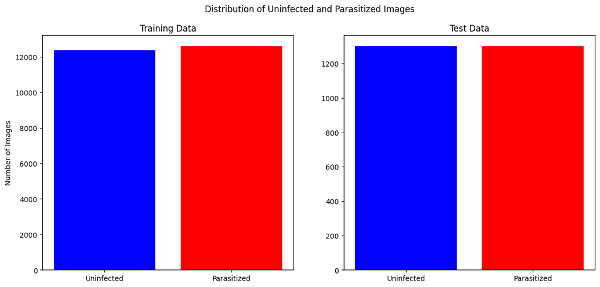

```python
# Create the plot
fig, ax = plt.subplots(1, 2, figsize=(14, 6))

# Training data
ax[0].bar(['Uninfected', 'Parasitized'], [num_uninfected_train, num_parasitized_train], color=['blue', 'red'])
ax[0].set_title('Training Data')
ax[0].set_ylabel('Number of Images')

# Test data
ax[1].bar(['Uninfected', 'Parasitized'], [num_uninfected_test, num_parasitized_test], color=['blue', 'red'])
ax[1].set_title('Test Data')

plt.suptitle('Distribution of Uninfected and Parasitized Images')
plt.show()
```

#### **Observations and insights:**

- The data seem to be balanced.

### **Data Exploration**

Let's visualize the images from the train data

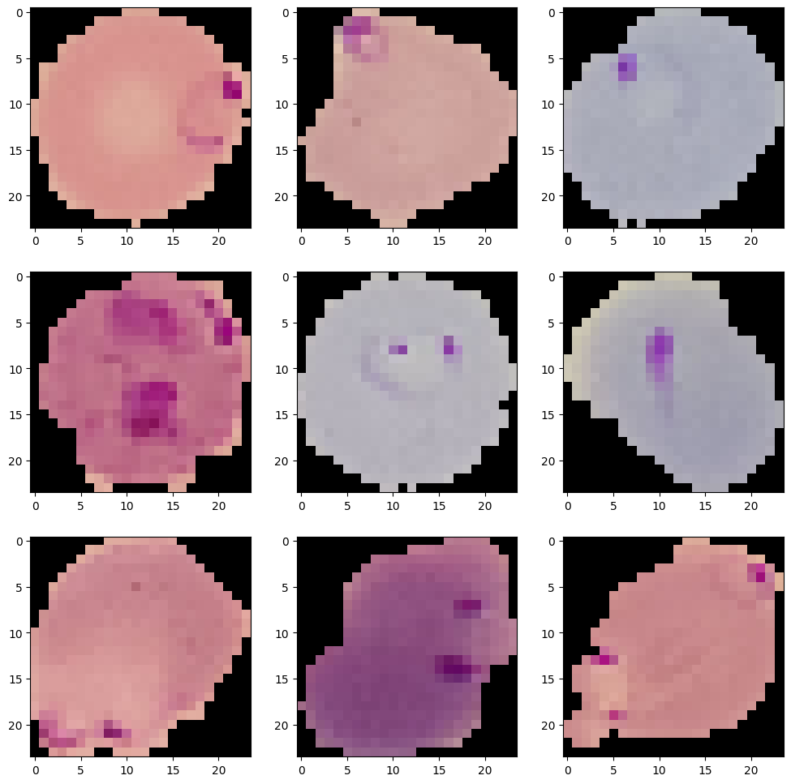

```python
# Visualizing the parasitized images in  train data

# Set the paths for the training data

train_path = '/content/drive/MyDrive/MITdataScienceCourse/scripts/Capstone_project/cell_images/train'
parasitized_path = os.path.join(train_path, 'parasitized')

picture_size = 24

# let us visualize the parasitized images
plt.figure(figsize = (12, 12))

for i in range(1, 10, 1):
    plt.subplot(3, 3, i)
    img = load_img(parasitized_path + "/" +
                  os.listdir(parasitized_path)[i], target_size = (picture_size, picture_size))
    plt.imshow(img)

plt.show()
```

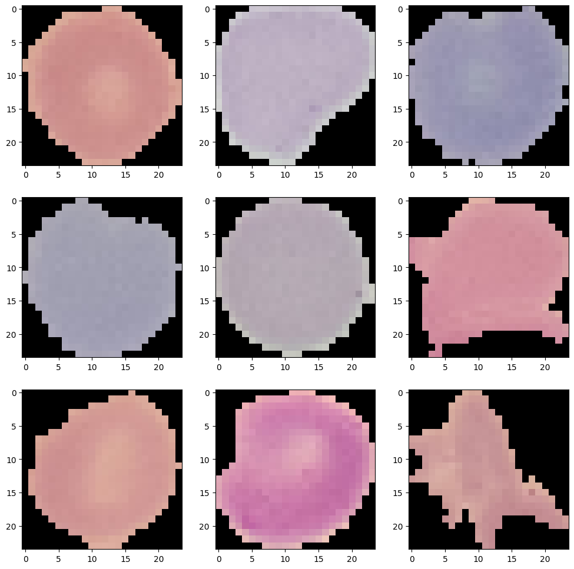

```python
# Set The paths for the uninfected images in the training data

train_path = '/content/drive/MyDrive/MITdataScienceCourse/scripts/Capstone_project/cell_images/train'

uninfected_path = os.path.join(train_path, 'uninfected')

picture_size = 24

# let us visualize the uninfected images
plt.figure(figsize = (12, 12))

for i in range(1, 10, 1):
    plt.subplot(3, 3, i)
    img = load_img(uninfected_path + "/" +
                  os.listdir(uninfected_path)[i], target_size = (picture_size, picture_size))
    plt.imshow(img)

plt.show()
```

#### **Observations and insights:**

- Most of the images are simple with no complicated feature.
- The shapes are in different orientations so augmentation might not be needed.

### **Visualize the images with subplot(6, 6) and figsize = (12, 12)**

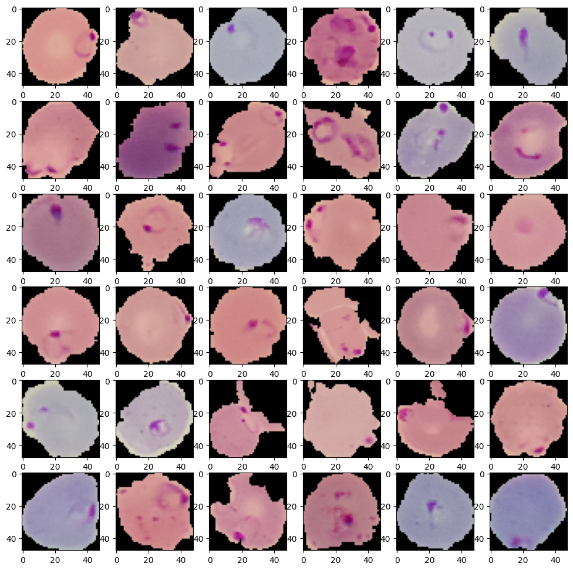

```python
# Visualizing the train data

# Set the paths for the training data

#train_path = '/content/drive/MyDrive/MITdataScienceCourse/scripts/Capstone_project/cell_images/train'
#parasitized_path = os.path.join(train_path, 'parasitized')
#uninfected_path = os.path.join(train_path, 'uninfected')

picture_size = 48

plt.figure(figsize = (12, 12))

for i in range(1, 37, 1):
    plt.subplot(6, 6, i)
    img = load_img(parasitized_path + "/" +
                  os.listdir(parasitized_path)[i], target_size = (picture_size, picture_size))
    plt.imshow(img)

plt.show()
```

### **Plotting the mean images for parasitized and uninfected**

```python
# Compute the mean image for each category
mean_parasitized = np.mean(parasitized_images, axis=0)
mean_uninfected = np.mean(uninfected_images, axis=0)
```

**Mean image for parasitized**

```
(-0.5, 31.5, 31.5, -0.5)
```

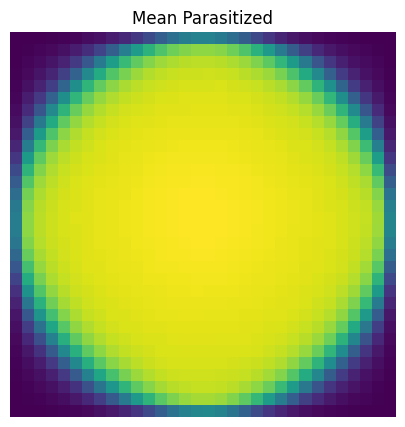

```python
# Plot the mean images for parasitized

plt.figure(figsize=(10, 5))

plt.imshow(mean_parasitized.squeeze())
plt.title('Mean Parasitized')
plt.axis('off')
```

**Mean image for uninfected**

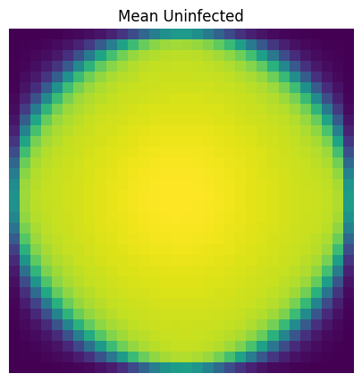

```python
# Plot the mean images for uninfected
plt.figure(figsize=(10, 5))

plt.imshow(mean_uninfected.squeeze())
plt.title('Mean Uninfected')
plt.axis('off')

plt.show()
```

### **Converting RGB to HSV of Images using OpenCV**

### **Converting the train data**

```python
def convert_rgb_to_hsv(images):

    # Initialize an empty list to store HSV images
    hsv_images = []

    for image in images:

        # Convert each grayscale image to RGB
        rgb_image = cv2.cvtColor(image, cv2.COLOR_GRAY2RGB)

        # Convert each RGB image to HSV
        hsv_image = cv2.cvtColor(rgb_image, cv2.COLOR_RGB2HSV)
        # Append the HSV image to the list
        hsv_images.append(hsv_image)

    # Convert the list to a numpy array
    hsv_images = np.array(hsv_images)

    return hsv_images

# Convert the images from RGB to HSV
train_images_hsv = convert_rgb_to_hsv(train_images)

print("Original train images shape:", train_images.shape)
print("Converted train images HSV shape:", train_images_hsv.shape)
```

```
Original train images shape: (24957, 32, 32, 1)
Converted train images HSV shape: (24957, 32, 32, 3)
```

```python
# Verify the pixel values after conversion

print("Shape:", train_images_hsv[0].shape)

print("First image:\n", train_images_hsv[0])
```

```
Shape: (32, 32, 3)
First image:
 [[[0. 0. 0.]
  [0. 0. 0.]
  [0. 0. 0.]
  ...
  [0. 0. 0.]
  [0. 0. 0.]
  [0. 0. 0.]]

 [[0. 0. 0.]
  [0. 0. 0.]
  [0. 0. 0.]
  ...
  [0. 0. 0.]
  [0. 0. 0.]
  [0. 0. 0.]]

 [[0. 0. 0.]
  [0. 0. 0.]
  [0. 0. 0.]
  ...
  [0. 0. 0.]
  [0. 0. 0.]
  [0. 0. 0.]]

 ...

 [[0. 0. 0.]
  [0. 0. 0.]
  [0. 0. 0.]
  ...
  [0. 0. 0.]
  [0. 0. 0.]
  [0. 0. 0.]]

 [[0. 0. 0.]
  [0. 0. 0.]
  [0. 0. 0.]
  ...
  [0. 0. 0.]
  [0. 0. 0.]
  [0. 0. 0.]]

 [[0. 0. 0.]
  [0. 0. 0.]
  [0. 0. 0.]
  ...
  [0. 0. 0.]
  [0. 0. 0.]
  [0. 0. 0.]]]
```

```python
# Check the minimum and maximum pixel values for train images
train_min = np.min(train_images_hsv)
train_max = np.max(train_images_hsv)

print(f'Train images pixel value range: Min = {train_min}, Max = {train_max}')
```

```
Train images pixel value range: Min = 0.0, Max = 0.886274516582489
```

### **Converting the test data**

```python
# Convert the images from RGB to HSV
test_images_hsv = convert_rgb_to_hsv(test_images)

print("Original train images shape:", test_images.shape)
print("Converted train images HSV shape:", test_images_hsv.shape)
```

```
Original train images shape: (2600, 32, 32, 1)
Converted train images HSV shape: (2600, 32, 32, 3)
```

#### **Observations and insights: **_****

1. The conversion between the 2 formats led to change in the number of channels from 1 (Grayscale) to 3 (HSV scale)

### **Processing Images using Gaussian Blurring**

### **Gaussian Blurring on train data**

```python
def apply_gaussian_blur(images, kernel_size=(5, 5)):
    blurred_images = []
    for img in images:
        blurred_img = cv2.GaussianBlur(img, kernel_size, 0)
        blurred_images.append(blurred_img)
    return np.array(blurred_images)

# Assuming train_images is a 4D numpy array of shape (num_samples, height, width, channels)
train_images_blurred = apply_gaussian_blur(train_images_hsv)

# Check the shape of the new array to ensure the blurring was successful
print(f'Training images shape (blurred): {train_images_blurred.shape}')
```

```
Training images shape (blurred): (24957, 32, 32, 3)
```

### **Gaussian Blurring on test data**

```python
# Assuming train_images is a 4D numpy array of shape (num_samples, height, width, channels)
test_images_blurred = apply_gaussian_blur(test_images_hsv)

# Check the shape of the new array to ensure the blurring was successful
print(f'Training images shape (blurred): {test_images_blurred.shape}')
```

```
Training images shape (blurred): (2600, 32, 32, 3)
```

**Think About It:** Would blurring help us for this problem statement in any way? What else can we try?

## **Model Building**

### **Base Model**

**Note:** The Base Model has been fully built and evaluated with all outputs shown to give an idea about the process of the creation and evaluation of the performance of a CNN architecture. A similar process can be followed in iterating to build better-performing CNN architectures.

### **Importing the required libraries for building and training our Model**

```python
import tensorflow as tf
from tensorflow.keras.models import Sequential
from tensorflow.keras.layers import Conv2D, MaxPooling2D, Flatten, Dense, Dropout
```

#### **One Hot Encoding the train and test labels**

```python
# Convert labels to categorical (one-hot encoding)
train_labels = to_categorical(train_labels, num_classes=2)

# Convert labels to categorical (one-hot encoding)
test_labels = to_categorical(test_labels, num_classes=2)
```

# Clear the backend and set the seeds

```python
from tensorflow.keras import backend
# Clear backend
backend.clear_session()

np.random.seed(42)
import random
random.seed(42)
tf.random.set_seed(42)
```

### **Building the model**

```python
#
def build_base_cnn_model(input_shape=(32, 32, 3)):
    model = Sequential()

    # First Convolutional Layer
    model.add(Conv2D(32, (3, 3), padding='same', activation='relu', input_shape=input_shape))
    model.add(MaxPooling2D(pool_size=(2, 2)))

    # Second Convolutional Layer
    model.add(Conv2D(64, (3, 3), padding='same', activation='relu'))
    model.add(MaxPooling2D(pool_size=(2, 2)))

    # Third Convolutional Layer
    model.add(Conv2D(128, (3, 3), padding='same', activation='relu'))
    model.add(MaxPooling2D(pool_size=(2, 2)))

    # Flatten the output
    model.add(Flatten())

    # Dense Layer
    model.add(Dense(128, activation='relu'))

    # Dropout Layer
    model.add(Dropout(0.5))

    # Output Layer
    model.add(Dense(2,activation='softmax'))

    # Compile the model
    model.compile(optimizer=tf.keras.optimizers.Adam(learning_rate=0.001),
                  loss='categorical_crossentropy',
                  metrics=['accuracy'])

    return model

# Build the model
base_cnn_model = build_base_cnn_model()

# Print the model summary
base_cnn_model.summary()
```

```
Model: "sequential"
_________________________________________________________________
 Layer (type)                Output Shape              Param #
=================================================================
 conv2d (Conv2D)             (None, 32, 32, 32)        896

 max_pooling2d (MaxPooling2  (None, 16, 16, 32)        0
 D)

 conv2d_1 (Conv2D)           (None, 16, 16, 64)        18496

 max_pooling2d_1 (MaxPoolin  (None, 8, 8, 64)          0
 g2D)

 conv2d_2 (Conv2D)           (None, 8, 8, 128)         73856

 max_pooling2d_2 (MaxPoolin  (None, 4, 4, 128)         0
 g2D)

 flatten (Flatten)           (None, 2048)              0

 dense (Dense)               (None, 128)               262272

 dropout (Dropout)           (None, 128)               0

 dense_1 (Dense)             (None, 2)                 258

=================================================================
Total params: 355778 (1.36 MB)
Trainable params: 355778 (1.36 MB)
Non-trainable params: 0 (0.00 Byte)
_________________________________________________________________
```

### **Compiling the model**

```python
base_cnn_model.compile(loss = 'binary_crossentropy', optimizer = 'adam', metrics = ['accuracy'])
```

**Using Callbacks**

```python
callbacks = [EarlyStopping(monitor = 'val_loss', patience = 2),
             ModelCheckpoint('.mdl_wts.hdf5', monitor = 'val_loss', save_best_only = True)]
```

**Fit and train our Model**

```python
# Fit the model
history = base_cnn_model.fit(train_images_hsv, train_labels,
                             validation_split=0.2,
                             callbacks = callbacks,
                             batch_size=32,
                             epochs=20,
                             verbose=1)
```

### **Evaluating the model on test data**

```python
# Evaluate the model on test data
test_loss, test_accuracy = base_cnn_model.evaluate(test_images_hsv, test_labels)
print(f'Test accuracy: {test_accuracy}')
```

```
Test accuracy: 0.931538462638855
```

**Plotting the confusion matrix**

```
              precision    recall  f1-score   support

           0       0.99      0.87      0.93      1300
           1       0.88      0.99      0.94      1300

    accuracy                           0.93      2600
   macro avg       0.94      0.93      0.93      2600
weighted avg       0.94      0.93      0.93      2600
```

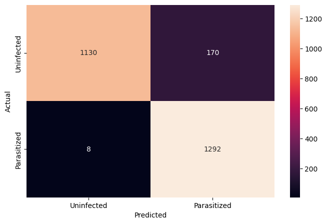

```python
from sklearn.metrics import classification_report

from sklearn.metrics import confusion_matrix


pred = base_cnn_model.predict(test_images_hsv)

pred = np.argmax(pred, axis = 1)

y_true = np.argmax(test_labels, axis = 1)

# Printing the classification report
print(classification_report(y_true, pred))

# Plotting the heatmap using confusion matrix
cm = confusion_matrix(y_true, pred)

plt.figure(figsize = (8, 5))

sns.heatmap(cm, annot = True,  fmt = '.0f', xticklabels = ['Uninfected', 'Parasitized'], yticklabels = ['Uninfected', 'Parasitized'])

plt.ylabel('Actual')

plt.xlabel('Predicted')

plt.show()
```

**Plotting the train and validation curves**

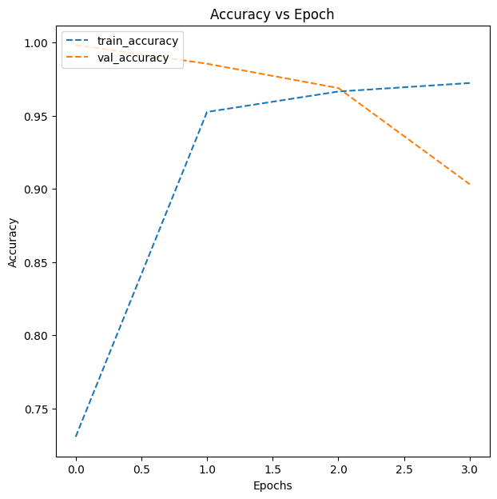

```python
# Function to plot train and validation accuracy
def plot_accuracy(history):

    N = len(history.history["accuracy"])

    plt.figure(figsize = (7, 7))

    plt.plot(np.arange(0, N), history.history["accuracy"], label = "train_accuracy", ls = '--')

    plt.plot(np.arange(0, N), history.history["val_accuracy"], label = "val_accuracy", ls = '--')

    plt.title("Accuracy vs Epoch")

    plt.xlabel("Epochs")

    plt.ylabel("Accuracy")

    plt.legend(loc="upper left")

plot_accuracy(history)
```

So now let's try to build another model with few more add on layers and try to check if we can try to improve the model. Therefore try to build a model by adding few layers if required and altering the activation functions.

### **Model 1**

#### **Trying to improve the performance of our model by adding new layers**

```python
# Clear the background from previous models
backend.clear_session()

np.random.seed(42)
import random
random.seed(42)
tf.random.set_seed(42)
```

### **Building the Model**

```python
# building the model
def build_improved_cnn_model(input_shape=(32, 32, 3)):
    model = Sequential()

    # First Convolutional Block
    model.add(Conv2D(32, (3, 3), padding='same', activation='relu', input_shape=input_shape))
    model.add(MaxPooling2D(pool_size=(2, 2)))
    model.add(Dropout(0.25))

    # Second Convolutional Block
    model.add(Conv2D(64, (3, 3), padding='same', activation='relu'))
    model.add(MaxPooling2D(pool_size=(2, 2)))
    model.add(Dropout(0.25))

    # Third Convolutional Block
    model.add(Conv2D(128, (3, 3), padding='same', activation='relu'))
    model.add(MaxPooling2D(pool_size=(2, 2)))
    model.add(Dropout(0.25))

    # Fourth Convolutional Block
    model.add(Conv2D(256, (3, 3), padding='same', activation='relu'))
    model.add(MaxPooling2D(pool_size=(2, 2)))
    model.add(Dropout(0.25))

    # Flatten the output
    model.add(Flatten())

    # First Dense Layer
    model.add(Dense(512, activation='relu'))
    model.add(Dropout(0.5))

    # Second Dense Layer
    model.add(Dense(128, activation='relu'))
    model.add(Dropout(0.5))

    # Output Layer
    model.add(Dense(2, activation='softmax'))


    return model

# Build the model
cnn_model1 = build_improved_cnn_model()

# Print the model summary
cnn_model1.summary()
```

```
Model: "sequential"
_________________________________________________________________
 Layer (type)                Output Shape              Param #
=================================================================
 conv2d (Conv2D)             (None, 32, 32, 32)        896

 max_pooling2d (MaxPooling2  (None, 16, 16, 32)        0
 D)

 dropout (Dropout)           (None, 16, 16, 32)        0

 conv2d_1 (Conv2D)           (None, 16, 16, 64)        18496

 max_pooling2d_1 (MaxPoolin  (None, 8, 8, 64)          0
 g2D)

 dropout_1 (Dropout)         (None, 8, 8, 64)          0

 conv2d_2 (Conv2D)           (None, 8, 8, 128)         73856

 max_pooling2d_2 (MaxPoolin  (None, 4, 4, 128)         0
 g2D)

 dropout_2 (Dropout)         (None, 4, 4, 128)         0

 conv2d_3 (Conv2D)           (None, 4, 4, 256)         295168

 max_pooling2d_3 (MaxPoolin  (None, 2, 2, 256)         0
 g2D)

 dropout_3 (Dropout)         (None, 2, 2, 256)         0

 flatten (Flatten)           (None, 1024)              0

 dense (Dense)               (None, 512)               524800

 dropout_4 (Dropout)         (None, 512)               0

 dense_1 (Dense)             (None, 128)               65664

 dropout_5 (Dropout)         (None, 128)               0

 dense_2 (Dense)             (None, 2)                 258

=================================================================
Total params: 979138 (3.74 MB)
Trainable params: 979138 (3.74 MB)
Non-trainable params: 0 (0.00 Byte)
_________________________________________________________________
```

### **Compiling the model**

```python
# Compile the model
cnn_model1.compile(optimizer=tf.keras.optimizers.Adam(learning_rate=0.001),
                  loss='categorical_crossentropy',
                  metrics=['accuracy'])
```

**Using Callbacks**

```python
callbacks = [EarlyStopping(monitor = 'val_loss', patience = 2),
             ModelCheckpoint('.mdl_wts.hdf5', monitor = 'val_loss', save_best_only = True)]
```

**Fit and Train the model**

```python
# Fit the model
history2 = cnn_model1.fit(train_images_hsv, train_labels,
                             validation_split=0.2,
                             callbacks = callbacks,
                             batch_size=32,
                             epochs=20,
                             verbose=1)
```

### **Evaluating the model**

```python
accuracy1 = cnn_model1.evaluate(train_images_hsv, train_labels, verbose = 1)

print('\n', 'Test_Accuracy:-', accuracy1[1])
```

```
 Test_Accuracy:- 0.6453099250793457
```

**Plotting the confusion matrix**

```
              precision    recall  f1-score   support

           0       0.82      0.26      0.39      1300
           1       0.56      0.94      0.70      1300

    accuracy                           0.60      2600
   macro avg       0.69      0.60      0.55      2600
weighted avg       0.69      0.60      0.55      2600
```

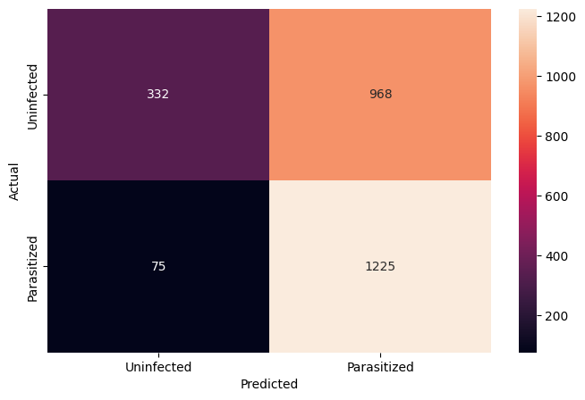

```python
pred = cnn_model1.predict(test_images_hsv)

pred = np.argmax(pred, axis = 1)

y_true = np.argmax(test_labels, axis = 1)

# Printing the classification report
print(classification_report(y_true, pred))

# Plotting the heatmap using confusion matrix
cm = confusion_matrix(y_true, pred)

plt.figure(figsize = (8, 5))

sns.heatmap(cm, annot = True,  fmt = '.0f', xticklabels = ['Uninfected', 'Parasitized'], yticklabels = ['Uninfected', 'Parasitized'])

plt.ylabel('Actual')

plt.xlabel('Predicted')

plt.show()
```

**Plotting the train and the validation curves**

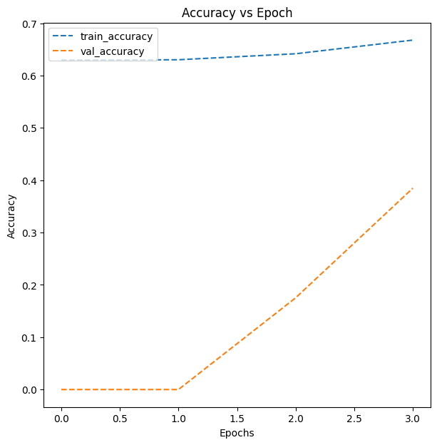

```python
# Function to plot train and validation accuracy
def plot_accuracy(history):

    N = len(history.history["accuracy"])

    plt.figure(figsize = (7, 7))

    plt.plot(np.arange(0, N), history.history["accuracy"], label = "train_accuracy", ls = '--')

    plt.plot(np.arange(0, N), history.history["val_accuracy"], label = "val_accuracy", ls = '--')

    plt.title("Accuracy vs Epoch")

    plt.xlabel("Epochs")

    plt.ylabel("Accuracy")

    plt.legend(loc="upper left")

plot_accuracy(history2)
```

**Observations:**

### **Think about it:**

Now let's build a model with LeakyRelu as the activation function

- Can the model performance be improved if we change our activation function to LeakyRelu?
- Can BatchNormalization improve our model?

Let us try to build a model using BatchNormalization and using LeakyRelu as our activation function.

### **Model 2 with Batch Normalization**

```python
# # Clear the background from previous models
backend.clear_session()

np.random.seed(42)
import random
random.seed(42)
tf.random.set_seed(42)
```

### **Building the Model**

```python
def cnn_model_withBatchNor(input_shape=(32, 32, 3)):
    model = Sequential()

    # First Convolutional Block
    model.add(Conv2D(32, (3, 3), padding='same', input_shape=input_shape))
    model.add(BatchNormalization())
    model.add(LeakyReLU(alpha=0.1))
    model.add(MaxPooling2D(pool_size=(2, 2)))
    model.add(Dropout(0.25))

    # Second Convolutional Block
    model.add(Conv2D(64, (3, 3), padding='same'))
    model.add(BatchNormalization())
    model.add(LeakyReLU(alpha=0.1))
    model.add(MaxPooling2D(pool_size=(2, 2)))
    model.add(Dropout(0.25))

    # Third Convolutional Block
    model.add(Conv2D(128, (3, 3), padding='same'))
    model.add(BatchNormalization())
    model.add(LeakyReLU(alpha=0.1))
    model.add(MaxPooling2D(pool_size=(2, 2)))
    model.add(Dropout(0.25))

    # Fourth Convolutional Block
    model.add(Conv2D(256, (3, 3), padding='same'))
    model.add(BatchNormalization())
    model.add(LeakyReLU(alpha=0.1))
    model.add(MaxPooling2D(pool_size=(2, 2)))
    model.add(Dropout(0.25))

    # Flatten the output
    model.add(Flatten())

    # First Dense Layer
    model.add(Dense(512))
    model.add(BatchNormalization())
    model.add(LeakyReLU(alpha=0.1))
    model.add(Dropout(0.5))

    # Second Dense Layer
    model.add(Dense(128))
    model.add(BatchNormalization())
    model.add(LeakyReLU(alpha=0.1))
    model.add(Dropout(0.5))

    # Output Layer
    model.add(Dense(2, activation='softmax'))

    return model

# Build the model
batchNormal_cnn_model = cnn_model_withBatchNor()

# Print the model summary
batchNormal_cnn_model.summary()
```

```
Model: "sequential"
_________________________________________________________________
 Layer (type)                Output Shape              Param #
=================================================================
 conv2d (Conv2D)             (None, 32, 32, 32)        896

 batch_normalization (Batch  (None, 32, 32, 32)        128
 Normalization)

 leaky_re_lu (LeakyReLU)     (None, 32, 32, 32)        0

 max_pooling2d (MaxPooling2  (None, 16, 16, 32)        0
 D)

 dropout (Dropout)           (None, 16, 16, 32)        0

 conv2d_1 (Conv2D)           (None, 16, 16, 64)        18496

 batch_normalization_1 (Bat  (None, 16, 16, 64)        256
 chNormalization)

 leaky_re_lu_1 (LeakyReLU)   (None, 16, 16, 64)        0

 max_pooling2d_1 (MaxPoolin  (None, 8, 8, 64)          0
 g2D)

 dropout_1 (Dropout)         (None, 8, 8, 64)          0

 conv2d_2 (Conv2D)           (None, 8, 8, 128)         73856

 batch_normalization_2 (Bat  (None, 8, 8, 128)         512
 chNormalization)

 leaky_re_lu_2 (LeakyReLU)   (None, 8, 8, 128)         0

 max_pooling2d_2 (MaxPoolin  (None, 4, 4, 128)         0
 g2D)

 dropout_2 (Dropout)         (None, 4, 4, 128)         0

```

[output cut: 24 more lines]

```

 batch_normalization_5 (Bat  (None, 128)               512
 chNormalization)

 leaky_re_lu_5 (LeakyReLU)   (None, 128)               0

 dropout_5 (Dropout)         (None, 128)               0

 dense_2 (Dense)             (None, 2)                 258

=================================================================
Total params: 983618 (3.75 MB)
Trainable params: 981378 (3.74 MB)
Non-trainable params: 2240 (8.75 KB)
_________________________________________________________________
```

### **Compiling the model**

```python
# Compile the model
batchNormal_cnn_model.compile(optimizer=tf.keras.optimizers.Adam(learning_rate=0.001),
                  loss='categorical_crossentropy',
                  metrics=['accuracy'])
```

**Using callbacks**

```python
callbacks = [EarlyStopping(monitor = 'val_loss', patience = 2),
             ModelCheckpoint('.mdl_wts.hdf5', monitor = 'val_loss', save_best_only = True)]
```

**Fit and train the model**

```python
# Fit the model
history3 = batchNormal_cnn_model.fit(train_images_hsv, train_labels,
                             validation_split=0.2,
                             #callbacks = callbacks,
                             batch_size=32,
                             epochs=20,
                             verbose=1)
```

### **Evaluating the model**

```python
accuracy1 = batchNormal_cnn_model.evaluate(train_images_hsv, train_labels, verbose = 1)

print('\n', 'Test_Accuracy:-', accuracy1[1])
```

```
 Test_Accuracy:- 0.9513563513755798
```

**Plotting the train and validation accuracy**

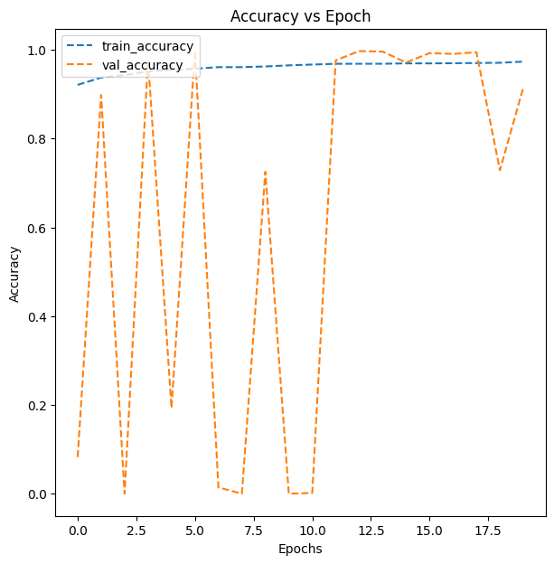

```python
# Function to plot train and validation accuracy
def plot_accuracy(history):

    N = len(history.history["accuracy"])

    plt.figure(figsize = (7, 7))

    plt.plot(np.arange(0, N), history.history["accuracy"], label = "train_accuracy", ls = '--')

    plt.plot(np.arange(0, N), history.history["val_accuracy"], label = "val_accuracy", ls = '--')

    plt.title("Accuracy vs Epoch")

    plt.xlabel("Epochs")

    plt.ylabel("Accuracy")

    plt.legend(loc="upper left")

plot_accuracy(history3)
```

**Generate the classification report and confusion matrix**

```
              precision    recall  f1-score   support

           0       0.99      0.87      0.93      1300
           1       0.88      1.00      0.94      1300

    accuracy                           0.93      2600
   macro avg       0.94      0.93      0.93      2600
weighted avg       0.94      0.93      0.93      2600
```

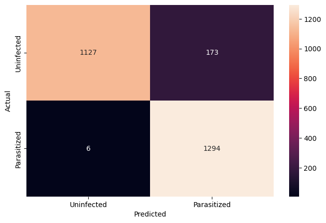

```python
pred = batchNormal_cnn_model.predict(test_images_hsv)

pred = np.argmax(pred, axis = 1)

y_true = np.argmax(test_labels, axis = 1)

# Printing the classification report
print(classification_report(y_true, pred))

# Plotting the heatmap using confusion matrix
cm = confusion_matrix(y_true, pred)

plt.figure(figsize = (8, 5))

sns.heatmap(cm, annot = True,  fmt = '.0f', xticklabels = ['Uninfected', 'Parasitized'], yticklabels = ['Uninfected', 'Parasitized'])

plt.ylabel('Actual')

plt.xlabel('Predicted')

plt.show()
```

#### **Observations and insights:**

- Overall, adding the activation function "LeakyReLU" seems to improve the stability of the performance of the training data.
- The test data shows large fluctuation in the accuracy as Epoch value increases.
- Most parasitized cells are predicted correctly, however 173 uninfected cells are predicted as parasitized.
- This model has better performance on both training and test data than the second model that added more layers.

### **Think About It :**

- Can we improve the model with Image Data Augmentation?
- References to image data augmentation can be seen below:
  - [Image Augmentation for Computer Vision](https://www.mygreatlearning.com/blog/understanding-data-augmentation/)
  - [How to Configure Image Data Augmentation in Keras?](https://machinelearningmastery.com/how-to-configure-image-data-augmentation-when-training-deep-learning-neural-networks/)

### **Model 3 with Data Augmentation**

```python
# # Clear the background from previous models
# backend.clear_session()
# np.random.seed(42)
# import random
# random.seed(42)
# tf.random.set_seed(42)
```

### **Use image data generator**

```python
# Creating two different lists to store the Numpy arrays and the corresponding labels
X_train = []
y_train = []

np.random.shuffle(train_images_hsv)           # Shuffling data to reduce variance and making sure that model remains general and overfit less
for features in train_images_hsv:      # Iterating over the training data which is generated from the create_training_data() function
    X_train.append(features)                  # Appending images into X_train
    #y_train.append(label)

for label in train_labels:      # Iterating over the training data which is generated from the create_training_data() function
    y_train.append(label)                  # Appending images into X_train

# Converting the pixel values into Numpy array
X_train = np.array(X_train)

X_train.shape
```

```
(24957, 32, 32, 3)
```

```python
# Creating two different lists to store the Numpy arrays and the corresponding labels
X_test = []
y_test = []

np.random.shuffle(test_images_hsv)        # Shuffling data to reduce variance and making sure that model remains general and overfit less
for features in test_images_hsv:          # Iterating over the training data which is generated from the create_training_data() function
    X_test.append(features)                # Appending images into X_train


for label in test_labels:                # Iterating over the training data which is generated from the create_training_data() function
    y_test.append(label)                  # Appending images into X_train

# Converting the pixel values into Numpy array
X_test = np.array(X_test)

X_test.shape
```

```
(2600, 32, 32, 3)
```

```python
# Using imagegenerator

from tensorflow.keras.preprocessing.image import ImageDataGenerator

# Using ImageDataGenerator to generate images
train_datagen = ImageDataGenerator(horizontal_flip = True,
                                  zoom_range = 0.5, rotation_range = 30)

val_datagen  = ImageDataGenerator()

# Flowing training images using train_datagen generator
train_generator = train_datagen.flow(x = X_train, y = y_train, batch_size = 32, seed = 42, shuffle = True)


# Flowing validation images using val_datagen generator
val_generator =  val_datagen.flow(x = X_test, y = y_test, batch_size = 32, seed = 42, shuffle = True)
```

### **Think About It :**

- Check if the performance of the model can be improved by changing different parameters in the ImageDataGenerator.

#### **Visualizing Augmented images**

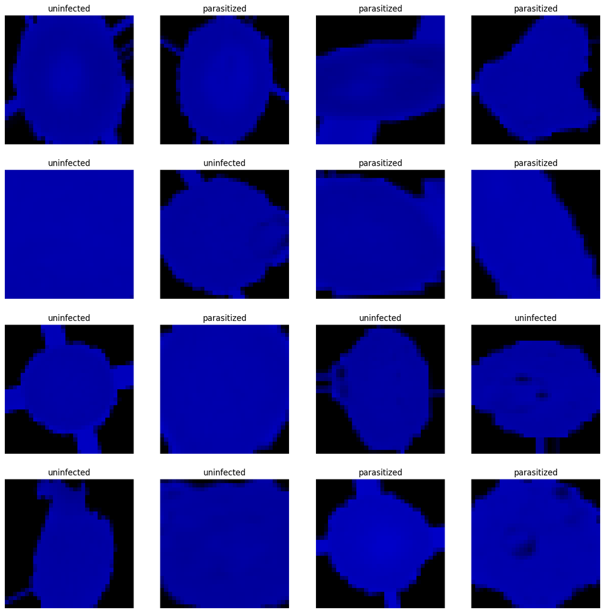

```python
# Creating an iterable for images and labels from the training data
images, labels = next(train_generator)

# Plotting 16 images from the training data
fig, axes = plt.subplots(4, 4, figsize = (16, 8))

fig.set_size_inches(16, 16)
for (image, label, ax) in zip(images, labels, axes.flatten()):

    ax.imshow(image)

    if label[1] == 1:

        ax.set_title('parasitized')

    else:

        ax.set_title('uninfected')

    ax.axis('off')
```

### **Building the Model**

```python
from tensorflow.keras.optimizers import Adam
adam = keras.optimizers.Adam(learning_rate = 0.001)

def cnn_model_withBatchNorDataAugment(input_shape=(32, 32, 3)):
    model = Sequential()

    # First Convolutional Block
    model.add(Conv2D(32, (3, 3), padding='same', input_shape=input_shape))
    model.add(BatchNormalization())
    model.add(LeakyReLU(alpha=0.1))
    model.add(MaxPooling2D(pool_size=(2, 2)))
    model.add(Dropout(0.25))

    # Second Convolutional Block
    model.add(Conv2D(64, (3, 3), padding='same'))
    model.add(BatchNormalization())
    model.add(LeakyReLU(alpha=0.1))
    model.add(MaxPooling2D(pool_size=(2, 2)))
    model.add(Dropout(0.25))

    # Third Convolutional Block
    model.add(Conv2D(128, (3, 3), padding='same'))
    model.add(BatchNormalization())
    model.add(LeakyReLU(alpha=0.1))
    model.add(MaxPooling2D(pool_size=(2, 2)))
    model.add(Dropout(0.25))

    # Fourth Convolutional Block
    model.add(Conv2D(256, (3, 3), padding='same'))
    model.add(BatchNormalization())
    model.add(LeakyReLU(alpha=0.1))
    model.add(MaxPooling2D(pool_size=(2, 2)))
    model.add(Dropout(0.25))

    # Flatten the output
    model.add(Flatten())

    # First Dense Layer
    model.add(Dense(512))
    model.add(BatchNormalization())
    model.add(LeakyReLU(alpha=0.1))
    model.add(Dropout(0.5))

    # Second Dense Layer
    model.add(Dense(128))
    model.add(BatchNormalization())
    model.add(LeakyReLU(alpha=0.1))
    model.add(Dropout(0.5))

    # Output Layer
    model.add(Dense(2, activation='softmax'))

    model.compile(loss = 'categorical_crossentropy', optimizer = adam, metrics = ['accuracy'])


    return model

# Build the model
dataAugmentBatchNormal_cnn_model = cnn_model_withBatchNorDataAugment()

# Print the model summary
dataAugmentBatchNormal_cnn_model.summary()
```

```
Model: "sequential_1"
_________________________________________________________________
 Layer (type)                Output Shape              Param #
=================================================================
 conv2d_4 (Conv2D)           (None, 32, 32, 32)        896

 batch_normalization_6 (Bat  (None, 32, 32, 32)        128
 chNormalization)

 leaky_re_lu_6 (LeakyReLU)   (None, 32, 32, 32)        0

 max_pooling2d_4 (MaxPoolin  (None, 16, 16, 32)        0
 g2D)

 dropout_6 (Dropout)         (None, 16, 16, 32)        0

 conv2d_5 (Conv2D)           (None, 16, 16, 64)        18496

 batch_normalization_7 (Bat  (None, 16, 16, 64)        256
 chNormalization)

 leaky_re_lu_7 (LeakyReLU)   (None, 16, 16, 64)        0

 max_pooling2d_5 (MaxPoolin  (None, 8, 8, 64)          0
 g2D)

 dropout_7 (Dropout)         (None, 8, 8, 64)          0

 conv2d_6 (Conv2D)           (None, 8, 8, 128)         73856

 batch_normalization_8 (Bat  (None, 8, 8, 128)         512
 chNormalization)

 leaky_re_lu_8 (LeakyReLU)   (None, 8, 8, 128)         0

 max_pooling2d_6 (MaxPoolin  (None, 4, 4, 128)         0
 g2D)

 dropout_8 (Dropout)         (None, 4, 4, 128)         0

```

[output cut: 24 more lines]

```

 batch_normalization_11 (Ba  (None, 128)               512
 tchNormalization)

 leaky_re_lu_11 (LeakyReLU)  (None, 128)               0

 dropout_11 (Dropout)        (None, 128)               0

 dense_5 (Dense)             (None, 2)                 258

=================================================================
Total params: 983618 (3.75 MB)
Trainable params: 981378 (3.74 MB)
Non-trainable params: 2240 (8.75 KB)
_________________________________________________________________
```

**Using Callbacks**

```python
callbacks = [EarlyStopping(monitor = 'val_loss', patience = 2),
             ModelCheckpoint('.mdl_wts.hdf5', monitor = 'val_loss', save_best_only = True)]
```

**Fit and Train the model**

```python
# Fit the model
history4 = dataAugmentBatchNormal_cnn_model.fit(train_generator,
                             validation_data = val_generator,
                             #validation_split=0.2,
                             callbacks = callbacks,
                             batch_size=32,
                             epochs=20,
                             verbose=1)
```

### **Evaluating the model**

**Plot the train and validation accuracy**

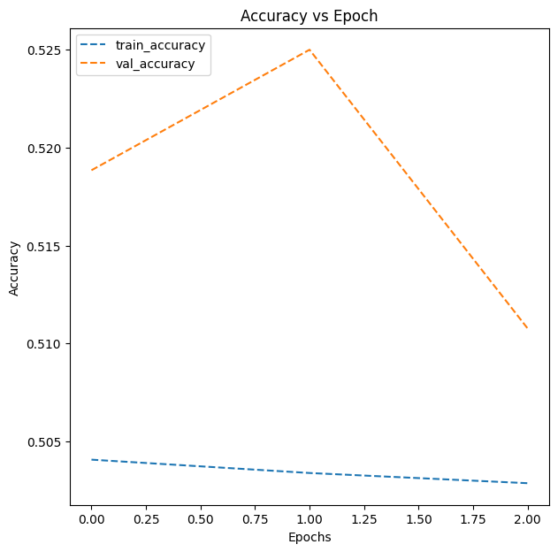

```python
# Function to plot train and validation accuracy
def plot_accuracy(history):

    N = len(history.history["accuracy"])

    plt.figure(figsize = (7, 7))

    plt.plot(np.arange(0, N), history.history["accuracy"], label = "train_accuracy", ls = '--')

    plt.plot(np.arange(0, N), history.history["val_accuracy"], label = "val_accuracy", ls = '--')

    plt.title("Accuracy vs Epoch")

    plt.xlabel("Epochs")

    plt.ylabel("Accuracy")

    plt.legend(loc="upper left")

plot_accuracy(history4)
```

**Plotting the classification report and confusion matrix**

```
              precision    recall  f1-score   support

           0       0.50      0.73      0.59      1300
           1       0.50      0.26      0.34      1300

    accuracy                           0.50      2600
   macro avg       0.50      0.50      0.47      2600
weighted avg       0.50      0.50      0.47      2600
```

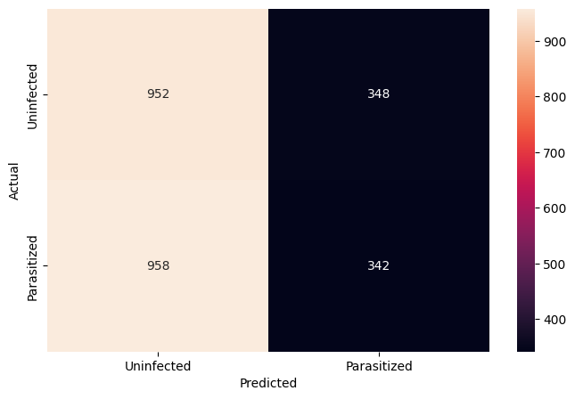

```python
pred = dataAugmentBatchNormal_cnn_model.predict(val_generator)

pred = np.argmax(pred, axis = 1)

y_true = np.argmax(test_labels, axis = 1)

# Printing the classification report
print(classification_report(y_true, pred))

# Plotting the heatmap using confusion matrix
cm = confusion_matrix(y_true, pred)

plt.figure(figsize = (8, 5))

sns.heatmap(cm, annot = True,  fmt = '.0f', xticklabels = ['Uninfected', 'Parasitized'], yticklabels = ['Uninfected', 'Parasitized'])

plt.ylabel('Actual')

plt.xlabel('Predicted')

plt.show()
```

**Observations:**

**Now, let us try to use a pretrained model like VGG16 and check how it performs on our data.**

```python
# Clearing backend
from tensorflow.keras import backend

backend.clear_session()

# Fixing the seed for random number generators
np.random.seed(42)

import random

random.seed(42)

tf.random.set_seed(42)
```

### **Pre-trained model (VGG16)**

- Import VGG16 network upto any layer you choose
- Add Fully Connected Layers on top of it

```python
from tensorflow.keras.applications.vgg16 import VGG16

from tensorflow.keras import Model
```

```python
transfer_layer = vgg.get_layer('block5_pool')

vgg.trainable = False

# Add classification layers on top of it
x = Flatten()(transfer_layer.output)  # Flatten the output from the 3rd block of the VGG16 model

x = Dense(256, activation = 'relu')(x)

# Similarly add a dense layer with 128 neurons
x = Dropout(0.3)(x)

# Add a dense layer with 64 neurons
x = BatchNormalization()(x)

pred = Dense(2, activation = 'softmax')(x)

vgg_model = Model(vgg.input, pred) # Initializing the model


vgg_model.summary()
```

```
Model: "model_2"
_________________________________________________________________
 Layer (type)                Output Shape              Param #
=================================================================
 input_2 (InputLayer)        [(None, 32, 32, 3)]       0

 block1_conv1 (Conv2D)       (None, 32, 32, 64)        1792

 block1_conv2 (Conv2D)       (None, 32, 32, 64)        36928

 block1_pool (MaxPooling2D)  (None, 16, 16, 64)        0

 block2_conv1 (Conv2D)       (None, 16, 16, 128)       73856

 block2_conv2 (Conv2D)       (None, 16, 16, 128)       147584

 block2_pool (MaxPooling2D)  (None, 8, 8, 128)         0

 block3_conv1 (Conv2D)       (None, 8, 8, 256)         295168

 block3_conv2 (Conv2D)       (None, 8, 8, 256)         590080

 block3_conv3 (Conv2D)       (None, 8, 8, 256)         590080

 block3_pool (MaxPooling2D)  (None, 4, 4, 256)         0

 block4_conv1 (Conv2D)       (None, 4, 4, 512)         1180160

 block4_conv2 (Conv2D)       (None, 4, 4, 512)         2359808

 block4_conv3 (Conv2D)       (None, 4, 4, 512)         2359808

 block4_pool (MaxPooling2D)  (None, 2, 2, 512)         0

 block5_conv1 (Conv2D)       (None, 2, 2, 512)         2359808

 block5_conv2 (Conv2D)       (None, 2, 2, 512)         2359808

 block5_conv3 (Conv2D)       (None, 2, 2, 512)         2359808

 block5_pool (MaxPooling2D)  (None, 1, 1, 512)         0

 flatten_2 (Flatten)         (None, 512)               0

 dense_4 (Dense)             (None, 256)               131328

 dropout_2 (Dropout)         (None, 256)               0

 batch_normalization_2 (Bat  (None, 256)               1024
 chNormalization)

 dense_5 (Dense)             (None, 2)                 514

=================================================================
Total params: 14847554 (56.64 MB)
Trainable params: 132354 (517.01 KB)
Non-trainable params: 14715200 (56.13 MB)
_________________________________________________________________
```

### **Compiling the model**

```python
# Compile the model
vgg_model.compile(optimizer=Adam(learning_rate=0.0001),
              loss='categorical_crossentropy',
              metrics=['accuracy'])
```

**using callbacks**

```python
callbacks = [EarlyStopping(monitor = 'val_loss', patience = 2),
             ModelCheckpoint('.mdl_wts.hdf5', monitor = 'val_loss', save_best_only = True)]
```

**Fit and Train the model**

```python
# Fitting the model and running the model for 10 epochs
history5 = vgg_model.fit(train_images_hsv,train_labels,
            epochs = 10,
            callbacks = callbacks,
            batch_size = 32,
            validation_split = 0.2,
            verbose = 1
)
```

**Plot the train and validation accuracy**

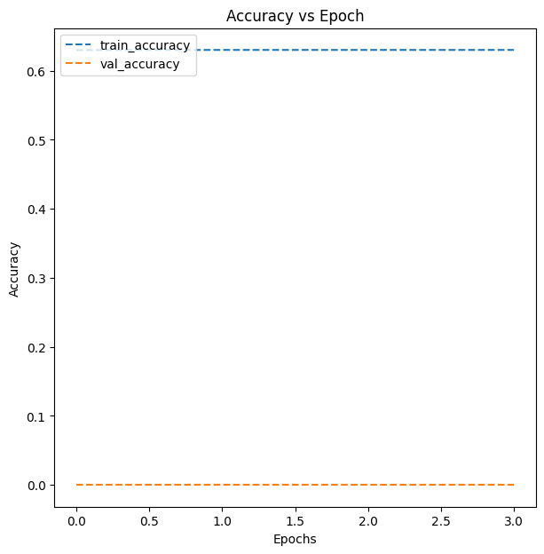

```python
# Function to plot train and validation accuracy
def plot_accuracy(history):

    N = len(history.history["accuracy"])

    plt.figure(figsize = (7, 7))

    plt.plot(np.arange(0, N), history.history["accuracy"], label = "train_accuracy", ls = '--')

    plt.plot(np.arange(0, N), history.history["val_accuracy"], label = "val_accuracy", ls = '--')

    plt.title("Accuracy vs Epoch")

    plt.xlabel("Epochs")

    plt.ylabel("Accuracy")

    plt.legend(loc="upper left")

plot_accuracy(history5)
```

### **Observations and insights: **_****

- What can be observed from the validation and train curves?
- The last model show relatively moderate performance on the training data, however it failed to work on the test data

### **Evaluating the model**

```python
accuracy1 = vgg_model.evaluate(train_images_hsv, train_labels, verbose = 1)

print('\n', 'Test_Accuracy:-', accuracy1[1])
```

```
 Test_Accuracy:- 0.5041471123695374
```

**Plotting the classification report and confusion matrix**

```
              precision    recall  f1-score   support

           0       0.00      0.00      0.00      1300
           1       0.50      1.00      0.67      1300

    accuracy                           0.50      2600
   macro avg       0.25      0.50      0.33      2600
weighted avg       0.25      0.50      0.33      2600
```

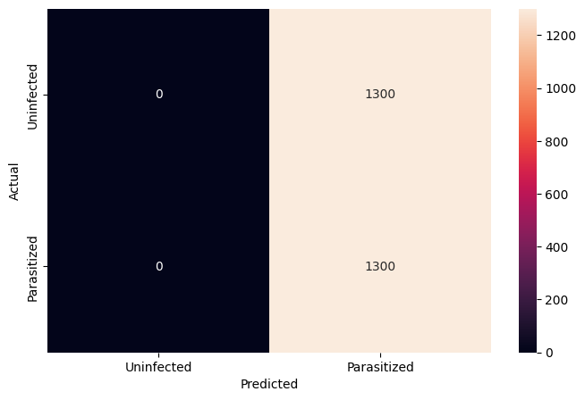

```python
pred = vgg_model.predict(test_images_hsv)

pred = np.argmax(pred, axis = 1)

y_true = np.argmax(test_labels, axis = 1)

# Printing the classification report
print(classification_report(y_true, pred))

# Plotting the heatmap using confusion matrix
cm = confusion_matrix(y_true, pred)

plt.figure(figsize = (8, 5))

sns.heatmap(cm, annot = True,  fmt = '.0f', xticklabels = ['Uninfected', 'Parasitized'], yticklabels = ['Uninfected', 'Parasitized'])

plt.ylabel('Actual')

plt.xlabel('Predicted')

plt.show()
```

### **Think about it:**

- What observations and insights can be drawn from the confusion matrix and classification report?

*- Performance of the model is poor as explained as the model faild to predict uninfected cells*

- Choose the model with the best accuracy scores from all the above models and save it as a final model.

#### **Observations and Conclusions drawn from the final model:**

- The best model in terms of performance out of all the tried models is the 1st model.
- The 1st model showed a high accuracy in predicting both parasitized and uninfected cells as indicated in the confusion matrix.

**Improvements that can be done:**

- Can the model performance be improved using other pre-trained models or different CNN architecture?
  - The pretrained and other models I tried here didn't improve the performance, however spending more time and tweeking the parameters might lead to improvement, particularely trying to solve the overfitting issue.*
- You can try to build a model using these HSV images and compare them with your other models.

#### **Refined insights**:

- What are the most meaningful insights from the data relevant to the problem?
  - *CNN can solved such prediction problem, however to get the best performing model, you need to carefully build your model considering several parameters and probably try different setting.*

#### **Comparison of various techniques and their relative performance**:

- How do different techniques perform? Which one is performing relatively better? Is there scope to improve the performance further?
  - *The pretrained and other models I tried here didn't improve the performance, however spending more time and tweeking the parameters might lead to improvement, particularely trying to solve the overfitting issue.*

#### **Proposal for the final solution design**:

- What model do you propose to be adopted? Why is this the best solution to adopt?
  - *Based on the performance metrics and plots, the best model was the 1st model with few layers.
  - Perfomance of the other models could be imporved, provided you spend some time tweeking the parameters*